# Practical Machine Learning – Course project

## Introduction

The purpose of this project is to use accelerometer data from wearable devices to correctly identify the correct (or incorrect) execution of a barbell lift.

Data is taken from the Weight Lifting Exercises dataset available at http://groupware.les.inf.puc-rio.br/har.

## Load required packages

We will need the caret, rpart, and randomForest packages.

```r
library(caret)
library(rpart)
library(randomForest)
courseDir <- 'C:\\Users\\Scott\\My Documents\\coursera\\data_science_specialization\\practical_machine_learning\\'
projectDir <- paste0(courseDir, 'project')
setwd(projectDir)
```

## Read training and test data

Read the training and test data from CSV files.

```r
dfTrain <- read.csv('pml-training.csv', na.strings = c("", "NA"))
dfTest  <- read.csv('pml-testing.csv', na.strings = c("", "NA"))
```

## Feature reduction

We remove features with bogus data (any NA values) and the first seven features, which are non-informative.

```r
goodFeatures <- colSums(is.na(dfTrain)) == 0
dfTrain <- dfTrain[, goodFeatures]
dfTrain <- dfTrain[, -(1:7)]
```

## Cross-validation set

Here we create a cross-validation set for model comparison using a 70/30 split.

```r
trainIdx <- createDataPartition(y = dfTrain$classe, p = 0.7, list = FALSE)
dfTrainR <- dfTrain[trainIdx, ]  # "reduced" training set
dfValid  <- dfTrain[-trainIdx, ] # cross-validation set
```

## Classification tree

Here we fit a classification tree model using all the available features, and check its prediction accuracy on the cross-validation set.

```r
set.seed(1138)
treeFit  <- rpart(classe ~ ., data = dfTrainR, method = "class")
treePred <- predict(treeFit, dfValid, type = "class")
treeAcc  <- confusionMatrix(treePred, dfValid$classe)$overall[1]
print(treeAcc)
```

```
##  Accuracy
## 0.7391674
```

The accuracy is around 70%, so not great. This might be a consequence of overfitting, which can be improved with a random forests approach.

## Random forests

Here we use a random forests approach to fit a classification tree model, and check its prediction accuracy on the cross-validation set.

```r
set.seed(1138)
rfFit  <- randomForest(classe ~ ., data = dfTrainR, ntree = 200, importance = TRUE)
print(rfFit)
```

```
##
## Call:
##  randomForest(formula = classe ~ ., data = dfTrainR, ntree = 200,      importance = TRUE)
##                Type of random forest: classification
##                      Number of trees: 200
## No. of variables tried at each split: 7
##
##         OOB estimate of  error rate: 0.63%
## Confusion matrix:
##      A    B    C    D    E  class.error
## A 3903    2    0    1    0 0.0007680492
## B   18 2630   10    0    0 0.0105342363
## C    1   15 2376    4    0 0.0083472454
## D    0    0   26 2225    1 0.0119893428
## E    0    0    2    7 2516 0.0035643564
```

```r
rfPred <- predict(rfFit, dfValid, type = "class")
rfAcc  <- confusionMatrix(rfPred, dfValid$classe)$overall[1]
print(rfAcc)
```

```
##  Accuracy
## 0.9942226
```

The variable importance plot shows that the belt and dumbbell accelerometers tended to contribute more to the prediction.

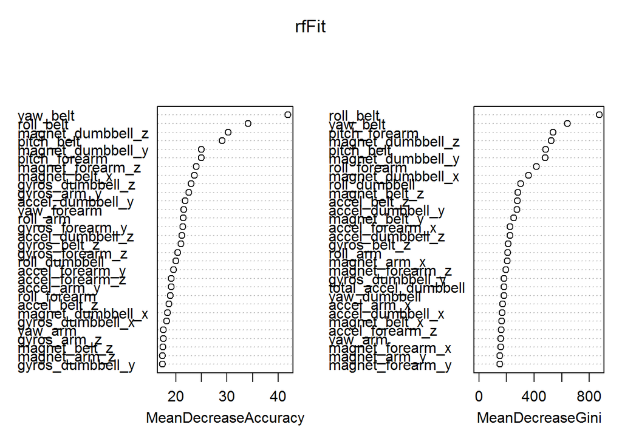

```r
varImpPlot(rfFit)
```

## Test set

The random forests model gives the following class predictions on the test set.

```r
rfTestPred <- predict(rfFit, dfTest, type = "class")
print(rfTestPred)
```

```
##  1  2  3  4  5  6  7  8  9 10 11 12 13 14 15 16 17 18 19 20
##  B  A  B  A  A  E  D  B  A  A  B  C  B  A  E  E  A  B  B  B
## Levels: A B C D E
```